# Titanic: Deck, Fare, and Embarkation Effects Beyond Class

Author

CLI Copilot

# Plan and Data

We address three questions using the Titanic dataset in `data/train.csv`:

1. Does cabin and deck information add signal beyond class and fare?
2. Is fare a proxy for wealth within class or does it carry independent survival signal?
3. Does the port of embarkation change survival patterns after controlling for who boards there?

We use tidyverse and ggplot2; tables are rendered with knitr::kable; a consistent minimalist theme is applied.

```r
library(tidyverse)
library(broom)
library(rsample)
library(yardstick)
library(knitr)
library(ggthemes)
library(here)

train <- read_csv(here::here("data","train.csv"))

train <- train %>%
  mutate(
    Sex = factor(Sex),
    Pclass = factor(Pclass),
    Survived = factor(Survived, levels = c(0,1), labels = c("No","Yes")),
    # Impute Age using median within Sex × Pclass; fallback to global median
    Age = ifelse(is.na(Age), ave(Age, Sex, Pclass, FUN = function(x){
      if(all(is.na(x))) median(train$Age, na.rm = TRUE) else median(x, na.rm = TRUE)
    }), Age),
    Child = as.integer(Age < 16),
    FamilySize = SibSp + Parch + 1,
    MissingCabin = is.na(Cabin),
    Deck = ifelse(MissingCabin, "Unknown", substr(Cabin, 1, 1))
  ) %>%
  mutate(
    Deck = ifelse(Deck %in% c("A","B","C","D","E","F","G"), Deck, "Unknown"),
    Deck = factor(Deck, levels = c("A","B","C","D","E","F","G","Unknown")),
    MissingCabin = factor(MissingCabin, levels = c(FALSE, TRUE), labels = c("Known","Missing"))
  )

theme_base <- theme_minimal(base_size = 12) + theme(legend.position = "bottom")
```

# 1) Deck and Cabin signal beyond class and fare

## EDA: Extract Deck and compare survival by Deck and MissingCabin, stratified by Pclass

We derive Deck as the first letter of Cabin and consider MissingCabin as a separate indicator. We examine survival rates by Deck and MissingCabin within each passenger class to test whether deck location adds signal after conditioning on class composition.

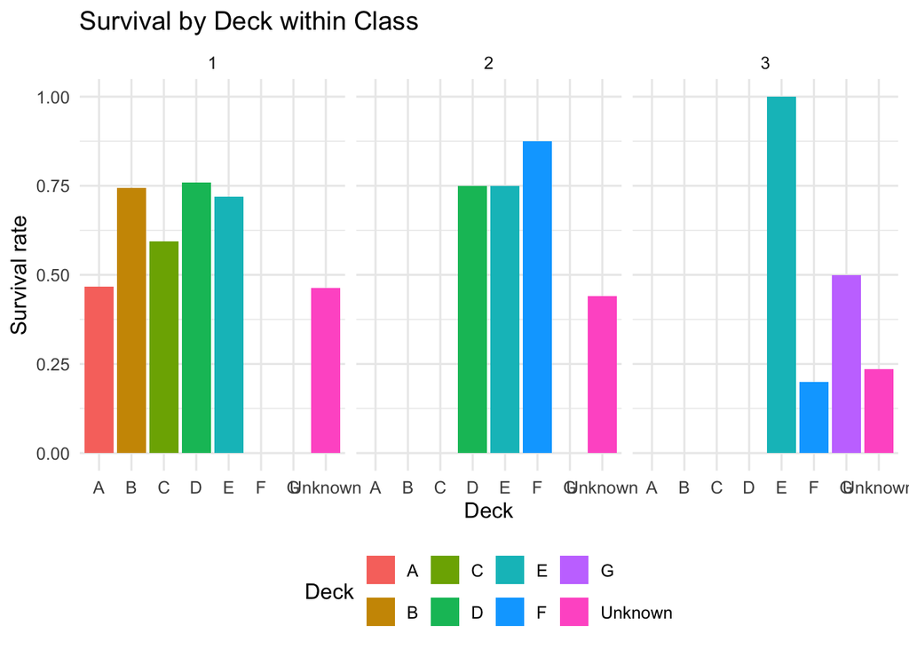

```r
eda_deck <- train %>%
  group_by(Pclass, Deck) %>%
  summarize(n = n(), surv_rate = mean(Survived == "Yes"), .groups = "drop")

ggplot(eda_deck, aes(Deck, surv_rate, fill = Deck)) +
  geom_col() +
  facet_wrap(~ Pclass, nrow = 1) +
  labs(title = "Survival by Deck within Class", x = "Deck", y = "Survival rate") +
  theme_base
```

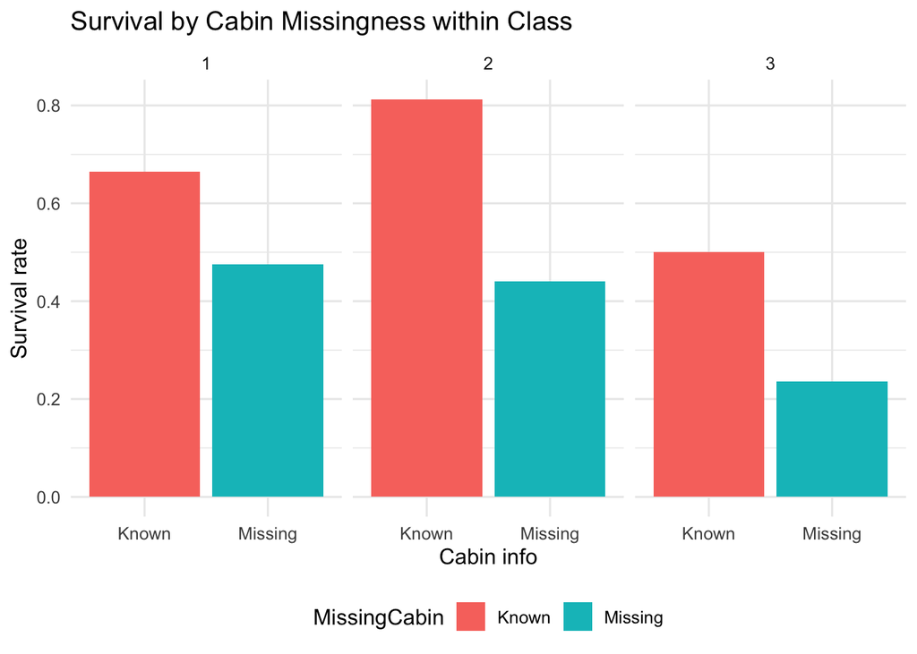

```r
eda_cabin_missing <- train %>%
  group_by(Pclass, MissingCabin) %>%
  summarize(n = n(), surv_rate = mean(Survived == "Yes"), .groups = "drop")

ggplot(eda_cabin_missing, aes(MissingCabin, surv_rate, fill = MissingCabin)) +
  geom_col(position = position_dodge(width = 0.8)) +
  facet_wrap(~ Pclass, nrow = 1) +
  labs(title = "Survival by Cabin Missingness within Class", x = "Cabin info", y = "Survival rate") +
  theme_base
```

## Model: Add Deck and MissingCabin; cross-validation gain and importance

We compare a baseline model using Sex, Pclass, Age, and Fare with an augmented model that includes Deck and MissingCabin. Five-fold CV reports accuracy and ROC AUC; we inspect coefficients to assess the incremental contribution.

```r
set.seed(42)
folds <- vfold_cv(train, v = 5, strata = Survived)

cv_metrics <- function(formula){
  map_dfr(folds$splits, function(s){
    tr <- analysis(s); te <- assessment(s)
    # Ensure consistent factor levels across folds to avoid new-level errors
    tr <- tr %>% mutate(
      Deck = factor(Deck, levels = levels(train$Deck)),
      MissingCabin = factor(MissingCabin, levels = levels(train$MissingCabin)),
      Embarked = factor(Embarked, levels = levels(train$Embarked))
    )
    te <- te %>% mutate(
      Deck = factor(Deck, levels = levels(train$Deck)),
      MissingCabin = factor(MissingCabin, levels = levels(train$MissingCabin)),
      Embarked = factor(Embarked, levels = levels(train$Embarked))
    )
    fit <- glm(formula, data = tr, family = binomial())
    # Map unseen factor levels in te to a valid baseline level to avoid xlevels errors
    te <- te %>% mutate(
      Deck = {
        lv <- levels(tr$Deck); d <- as.character(Deck); d[!d %in% lv] <- lv[1]; factor(d, levels = lv)
      },
      MissingCabin = {
        lv <- levels(tr$MissingCabin); mc <- as.character(MissingCabin); mc[!mc %in% lv] <- lv[1]; factor(mc, levels = lv)
      },
      Embarked = {
        lv <- levels(tr$Embarked); e <- as.character(Embarked); e[!e %in% lv] <- lv[1]; factor(e, levels = lv)
      }
    )
    prob <- predict(fit, newdata = te, type = "response")
    pred <- factor(ifelse(prob > 0.5, "Yes", "No"), levels = c("No","Yes"))
    tibble(
      accuracy = yardstick::accuracy_vec(te$Survived, pred),
      roc_auc = yardstick::roc_auc_vec(te$Survived, prob, event_level = "second")
    )
  }) %>% summarize(across(everything(), mean))
}

f_baseline <- Survived ~ Sex + Pclass + Age + Fare
f_deck     <- Survived ~ Sex + Pclass + Age + Fare + Deck + MissingCabin

m_baseline <- cv_metrics(f_baseline)
m_deck     <- cv_metrics(f_deck)

bind_rows(
  m_baseline %>% mutate(model = "Baseline"),
  m_deck %>% mutate(model = "+Deck+MissingCabin")
) %>% select(model, accuracy, roc_auc) %>% knitr::kable(digits = 3)
```

| model | accuracy | roc_auc |
| --- | --- | --- |
| Baseline | 0.798 | 0.847 |
| +Deck+MissingCabin | 0.797 | 0.847 |

```r
fit_full <- glm(f_deck, data = train, family = binomial())
tidy(fit_full, exponentiate = TRUE, conf.int = TRUE) %>%
  arrange(desc(estimate)) %>%
  knitr::kable(digits = 3, caption = "Odds ratios (augmented model)")
```

Odds ratios (augmented model)

| term | estimate | std.error | statistic | p.value | conf.low | conf.high |
| --- | --- | --- | --- | --- | --- | --- |
| MissingCabinMissing | 232374.140 | 535.411 | 0.023 | 0.982 | 0.000 | NA |
| (Intercept) | 49.610 | 0.692 | 5.642 | 0.000 | 12.726 | 1.967300e+02 |
| DeckE | 2.051 | 0.729 | 0.986 | 0.324 | 0.497 | 8.869000e+00 |
| DeckD | 1.431 | 0.731 | 0.490 | 0.624 | 0.346 | 6.210000e+00 |
| DeckF | 1.310 | 0.988 | 0.273 | 0.785 | 0.189 | 9.280000e+00 |
| DeckB | 1.014 | 0.707 | 0.019 | 0.985 | 0.254 | 4.151000e+00 |
| Fare | 1.001 | 0.002 | 0.399 | 0.690 | 0.997 | 1.006000e+00 |
| Age | 0.963 | 0.008 | -4.749 | 0.000 | 0.948 | 9.780000e-01 |
| DeckC | 0.546 | 0.656 | -0.923 | 0.356 | 0.150 | 2.016000e+00 |
| Pclass2 | 0.537 | 0.421 | -1.477 | 0.140 | 0.237 | 1.242000e+00 |
| DeckG | 0.215 | 1.237 | -1.242 | 0.214 | 0.017 | 2.663000e+00 |
| Pclass3 | 0.161 | 0.427 | -4.274 | 0.000 | 0.070 | 3.750000e-01 |
| Sexmale | 0.075 | 0.191 | -13.542 | 0.000 | 0.051 | 1.090000e-01 |
| DeckUnknown | 0.000 | 535.411 | -0.025 | 0.980 | NA | 3.887432e+41 |

# 2) Fare: proxy within class or independent signal

## EDA: Survival vs Fare within each Pclass; compare fare quantiles per class

We visualize survival rate against Fare within each class and compute fare quantiles to understand within-class variation.

```r
train <- train %>% mutate(LogFare = log1p(Fare))

# Smooth survival vs Fare within class
eda_fare <- train %>%
  group_by(Pclass) %>%
  summarize(q = list(quantile(Fare, probs = seq(0,1,0.25), na.rm = TRUE)), .groups = "drop")

knitr::kable(unnest_wider(eda_fare, q), digits = 2, caption = "Fare quantiles by class")
```

Fare quantiles by class

| Pclass | 0% | 25% | 50% | 75% | 100% |
| --- | --- | --- | --- | --- | --- |
| 1 | 0 | 30.92 | 60.29 | 93.5 | 512.33 |
| 2 | 0 | 13.00 | 14.25 | 26.0 | 73.50 |
| 3 | 0 | 7.75 | 8.05 | 15.5 | 69.55 |

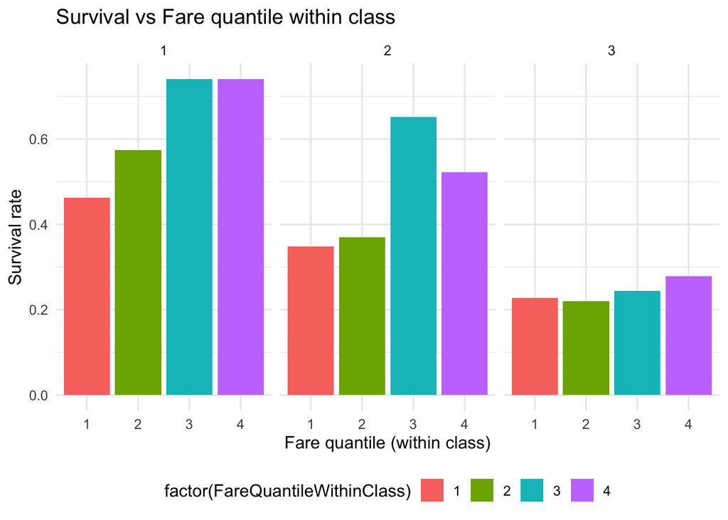

```r
# Bin fare within class into quantiles
train <- train %>% group_by(Pclass) %>%
  mutate(FareQuantileWithinClass = ntile(Fare, 4)) %>% ungroup()

eda_fare_surv <- train %>%
  group_by(Pclass, FareQuantileWithinClass) %>%
  summarize(n = n(), surv_rate = mean(Survived == "Yes"), .groups = "drop")

ggplot(eda_fare_surv, aes(factor(FareQuantileWithinClass), surv_rate, fill = factor(FareQuantileWithinClass))) +
  geom_col() + facet_wrap(~ Pclass, nrow = 1) +
  labs(title = "Survival vs Fare quantile within class", x = "Fare quantile (within class)", y = "Survival rate") +
  theme_base
```

## Model: Incremental value over class alone using LogFare and FareQuantileWithinClass

We test whether Fare carries signal beyond class using both continuous LogFare and categorical FareQuantileWithinClass.

```r
set.seed(42)
folds <- vfold_cv(train, v = 5, strata = Survived)

m_class_only <- cv_metrics(Survived ~ Pclass)
m_logfare    <- cv_metrics(Survived ~ Pclass + LogFare)
m_fareq      <- cv_metrics(Survived ~ Pclass + factor(FareQuantileWithinClass))

bind_rows(
  m_class_only %>% mutate(model = "Class only"),
  m_logfare %>% mutate(model = "+LogFare"),
  m_fareq %>% mutate(model = "+FareQuantileWithinClass")
) %>% select(model, accuracy, roc_auc) %>% knitr::kable(digits = 3)
```

| model | accuracy | roc_auc |
| --- | --- | --- |
| Class only | 0.679 | 0.682 |
| +LogFare | 0.698 | 0.714 |
| +FareQuantileWithinClass | 0.697 | 0.696 |

# 3) Embarkation effects after controlling composition

## EDA: Survival by Embarked; then condition on Pclass and Sex

We examine survival by port of embarkation overall and within strata of Pclass and Sex to identify composition vs within-port effects.

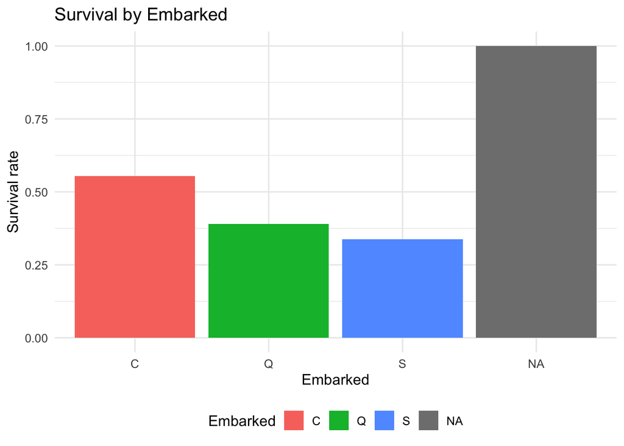

```r
train <- train %>% mutate(Embarked = factor(Embarked))

eda_embarked <- train %>% group_by(Embarked) %>%
  summarize(n = n(), surv_rate = mean(Survived == "Yes"), .groups = "drop")

ggplot(eda_embarked, aes(Embarked, surv_rate, fill = Embarked)) +
  geom_col() + labs(title = "Survival by Embarked", x = "Embarked", y = "Survival rate") + theme_base
```

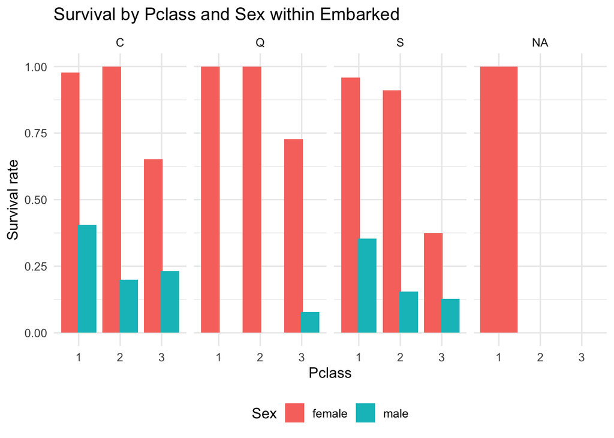

```r
eda_embarked_strata <- train %>% group_by(Embarked, Pclass, Sex) %>%
  summarize(n = n(), surv_rate = mean(Survived == "Yes"), .groups = "drop")

ggplot(eda_embarked_strata, aes(Pclass, surv_rate, fill = Sex)) +
  geom_col(position = position_dodge(width = 0.8)) +
  facet_wrap(~ Embarked, nrow = 1) +
  labs(title = "Survival by Pclass and Sex within Embarked", x = "Pclass", y = "Survival rate") +
  theme_base
```

## Model: Add Embarked and Embarked*Pclass; compare CV and inspect coefficients

```r
set.seed(42)
folds <- vfold_cv(train, v = 5, strata = Survived)

m_no_emb <- cv_metrics(Survived ~ Sex + Pclass + Age + Fare)
m_with_emb <- cv_metrics(Survived ~ Sex + Pclass + Age + Fare + Embarked + Embarked:Pclass)

bind_rows(
  m_no_emb %>% mutate(model = "No Embarked"),
  m_with_emb %>% mutate(model = "+Embarked + Embarked:Pclass")
) %>% select(model, accuracy, roc_auc) %>% knitr::kable(digits = 3)
```

| model | accuracy | roc_auc |
| --- | --- | --- |
| No Embarked | 0.798 | 0.847 |
| +Embarked + Embarked:Pclass | 0.788 | 0.839 |

```r
fit_emb_full <- glm(Survived ~ Sex + Pclass + Age + Fare + Embarked + Embarked:Pclass,
                    data = train, family = binomial())

tidy(fit_emb_full, exponentiate = TRUE, conf.int = TRUE) %>%
  arrange(desc(estimate)) %>%
  knitr::kable(digits = 3, caption = "Odds ratios with Embarked and interaction")
```

Odds ratios with Embarked and interaction

| term | estimate | std.error | statistic | p.value | conf.low | conf.high |
| --- | --- | --- | --- | --- | --- | --- |
| (Intercept) | 44.602 | 0.516 | 7.362 | 0.000 | 16.527 | 125.335 |
| Pclass2:EmbarkedQ | 5.997 | 2.581 | 0.694 | 0.488 | 0.044 | 1058.443 |
| Pclass3:EmbarkedQ | 2.279 | 1.886 | 0.437 | 0.662 | 0.050 | 103.868 |
| Pclass2:EmbarkedS | 1.098 | 0.724 | 0.130 | 0.897 | 0.268 | 4.614 |
| Fare | 1.000 | 0.002 | 0.142 | 0.887 | 0.996 | 1.005 |
| Age | 0.965 | 0.008 | -4.624 | 0.000 | 0.950 | 0.979 |
| EmbarkedS | 0.770 | 0.361 | -0.723 | 0.470 | 0.378 | 1.561 |
| Pclass3:EmbarkedS | 0.536 | 0.509 | -1.224 | 0.221 | 0.198 | 1.462 |
| EmbarkedQ | 0.313 | 1.836 | -0.633 | 0.527 | 0.007 | 13.061 |
| Pclass2 | 0.302 | 0.692 | -1.731 | 0.083 | 0.076 | 1.155 |
| Pclass3 | 0.140 | 0.493 | -3.987 | 0.000 | 0.052 | 0.363 |
| Sexmale | 0.078 | 0.190 | -13.373 | 0.000 | 0.054 | 0.113 |

# Notes

- Age imputation minimizes leakage by using strata without outcome.
- Deck is derived from Cabin first letter; MissingCabin captures information absence which may correlate with class and survival processes.
- Fare is log-transformed to reduce skew; quantiles within class isolate within-class price variation.
- Embarked effects are tested with interaction to separate composition from port-specific processes.